# Exploring the BRFSS data by Bindu G

## Setup

### Load packages

```r
library(ggplot2)
library(dplyr)
library(reshape2)
```

### Load data

Make sure your data and R Markdown files are in the same directory. When loaded your data file will be called `brfss2013`.

```r
load("C:/temp/brfss2013.RData")
```

## Part 1: Data

Data: BRFSS measured behavioral risk factors for non-institutionalized adult population (18 years of age and older) residing in US. Data was collected using landline and cellular telephone services.

In landline telephone survey, data is collected from a randomly selected adult in house hold by disproportionate stratified sampling. In cellular telephone survey interviewers collect data from an adult who resides in a private residence or college housing by simple random sampling which is not as efficient as the stratified sampling used for landline telephone survey.

Since random sampling is used, results can be generalized for the adults in US only but a causal inference can’t be made as there is no random assignment of individuals. Also,there may be bias in answering the questions about health conditions in lieu of privacy

## Part 2: Research questions

**Research quesion 1:** Any relation between age, gender and cholestrol? Does over weight people have high cholestrol as they get old? Is it more in men/women?

We assume that people who are having more weight than normal (fat people) will have higher chance of having cholestrol as they grow older in age.

**Research quesion 2:**

Does income earned impacts the health coverage? It is general notion that majority of high earning people will opt for health care than people who have lower income.

**Research quesion 3:** Is there any relationship between people’s sleeping habits and health condition (physical/mental)?

we suppose that people who had average 6-8 hours sleep a day will have better physical and mental health.

## Part 3: Exploratory data analysis

NOTE: Insert code chunks as needed by clicking on the “Insert a new code chunk” button (green button with orange arrow) above. Make sure that your code is visible in the project you submit. Delete this note when before you submit your work.

**Research quesion 1:**

variables to consider are- employ1: to figure out older people aka retired X_bmi5: calculated bmi field which helps to show if people are over weight/fat toldhi2: told blood cholestrol high sex: male/female we will consider only yes/no options for cholestrol indicator we will compute bmi percentage

```r
chol_bmi <-  brfss2013 %>% filter(employ1 == "Retired") %>% select(X_bmi5,toldhi2,sex) %>% filter(toldhi2 %in% c("Yes","No")) %>% mutate(bmi = X_bmi5/100)
```

chart the data as box plots to identify the trend of bmi among different sex

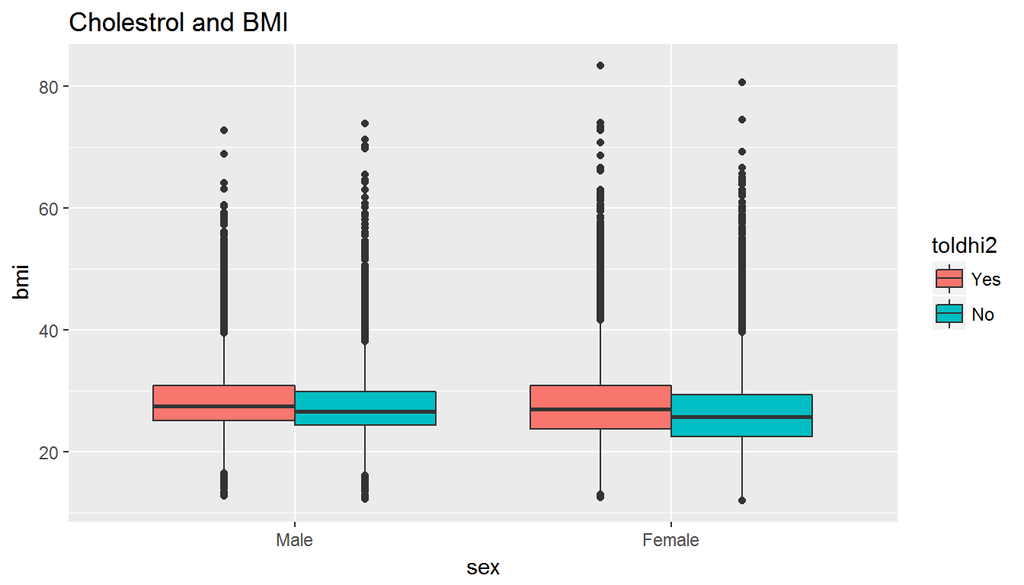

```r
ggplot(chol_bmi, aes(x = sex, y = bmi, fill = toldhi2)) + geom_boxplot() + ggtitle("Cholestrol and BMI")
```

It can be summarised from the plot (median) that both men and women told to have high cholestrol have highre BMI than people who are not being told among retired people. so it is evident that as over weight people (both men & women) get older they would have a chance of being told to have high cholestrol. Also, female population,older people with high cholestrol, have high variablity (IQR is wider than men).

**Research quesion 2:**

Variables to consider are- hlthpln1: if people have a health plan or not X_incomg: calculated income field that categorizes different income levels

we will consider only yes/no options for hlthpln1 and valid/non missing values for incomes earned we will count the number of people that are earning and have a health coverage or not

```r
hcov_inc <- brfss2013 %>% filter(!is.na(X_incomg),!is.na(hlthpln1)) %>% group_by(X_incomg,hlthpln1) %>% summarise(count=n())
```

Plot income levels vs healthplan coverage

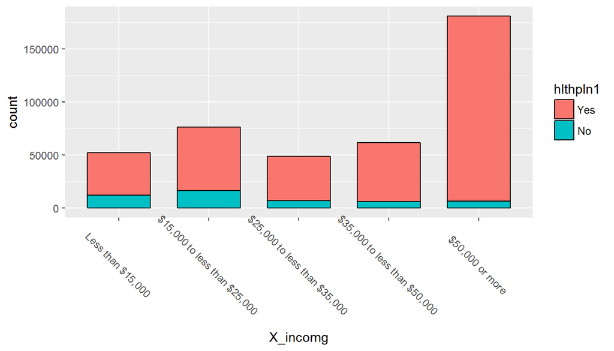

```r
ggplot(hcov_inc, aes(X_incomg), y=count) +
    geom_bar(aes(fill = hlthpln1, weight = count),  width = .7, color="black") + theme(axis.text.x = element_text(vjust=0.6,angle=-45))
```

Through the plot we can see that having health coverage ‘yes’ is more among the people who have more income. Ratio of having a helath coverage is high among high earning individuals, income more than 50000.

**Research quesion 3:**

variables to consider are- menthlth: no of days mental health not good physhlth: no of days mental health not good sleptim1:hours of sleep time

```r
sleep_hlth <- brfss2013 %>% filter(menthlth<30) %>% filter (physhlth<30) %>% filter (sleptim1<=24) %>% group_by(sleep_time=as.factor(sleptim1)) %>% summarise(bad_ment_hlth=mean(menthlth),bad_phys_hlth=mean(physhlth))
```

Reshape the data for creating comparative plots. Rename the ‘value’ to average_days to represent the mean of poor health days

```r
sleep_hlth <-melt(sleep_hlth)
names(sleep_hlth)[3] <- "Average_days"
```

plot the comparative histograms

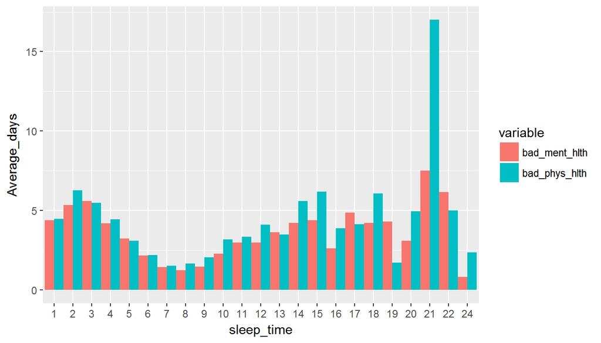

```r
ggplot(sleep_hlth,aes(x=sleep_time,y=Average_days,fill=variable)) + geom_bar(stat="identity",width=1,position="dodge")
```